# Analysis Report

## A) Introduction

I have a analysed a WeRateDogs dataset combining different sources of information: a csv, twitter API and a dog breed predictions table.

In order to focus my analysis I have chosen three questions. The questions have been chosen looking to extract interesting insights and combine different kinds of data. The questions are:

1. What dog stage has better ratings, retweets and favorites?
2. What breeds are the most popular? What breeds has better ratings, retweets and favorites?
3. What factors are related with having more reweets and favorites?

## B) Analysis Implementation

### B.1. What dog stage has better ratings, retweets and favorites?

For the first question I have created a Dataframe with the mean values of `rating_numerator`, `retweet_count` and `favorite_count`.

### B.2. What breeds are the most popular? What breeds has better ratings, retweets and favorites?

In order to analyse what dog breed has better ratings, first we should asign each dog a breed. As we don't want to minimize failing in the assignment of dog breed to each dog we are going to consider only dogs with a probability of detecting breeds greater than 0.5.

I have considered the most popular 10 dog breeds and I have kept all other under the category `other`.

### B.3. What factors are related with having more reweets and favorites?

I have created one lineal regression model for `retweet_count`and another one for `favorite_count` using `statsmodel.api.OLS` method.

In orther to do that I have created the corresponding dummy variables for `stage` and `p1`(breed).

I have obtained the following results:

[figure not shown]

favorite_count regression model results

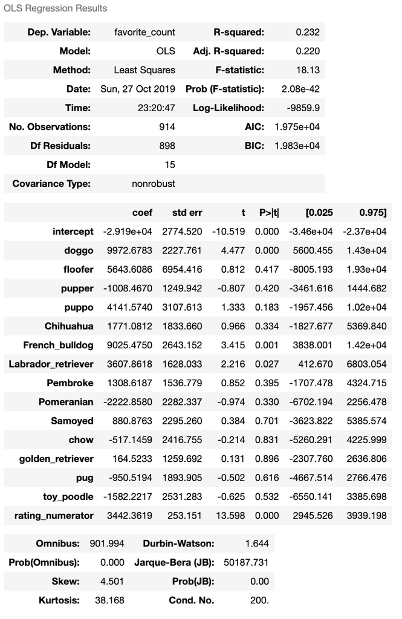

## C) Analysis Conclusions

### C.1. What dog stage has better ratings, retweets and favorites?

- All dog stages have similar rating average. The highest rating_average is for `puppo`
- `doggo`is the stage with higher average retweet count. The second one is `puppo`.
- `puppo`is the stage with higher average favorite count. The second one is `doggo`.

### C.2. What are the most popular breeds? What breed has better ratings, retweets and favorites?

- The most popular breed is `golden_retriever` followed by: `Pembroke`, `Labrador_retriever`, `Chihuahua`, `pug`, Pomerianian, `Samoyed`, `chow`, `toy_poodle`, `French_bulldog`.
- `Samoyed` is the breed with higher average rating.
- French Bulldog is the breed with higher average retweet count.
- French Bulldog is the breed with higher average favorite count.

### C.3. What factors are related with having more reweets and favorites?

- In both `rewteet_count` and `favorite_count` there are some factors with high influence. They are `rating_numerator`, `French_bulldog` breed, `Labrador_retriever` breed and `doggo` stage all with positive coeficients indicating a high positive influence in both `retweet_count` and `favorite_count`.